# Classifying_Email_SPAM_using_BERT

**A model to classify spam Email using BERT**

From Cisco: Spam email is unsolicited and unwanted junk email sent out in bulk to an indiscriminate recipient list. Typically, spam is sent for commercial purposes. It can be sent in massive volume by botnets, networks of infected computers.

[figure not shown]

**Why do people send out spam email?** Often, spam email is sent for commercial purposes. While some people view it as unethical, many businesses still use spam. The cost per email is incredibly low, and businesses can send out mass quantities consistently. Spam email can also be a malicious attempt to gain access to your computer.

**Is spam email dangerous?** Spam email can be dangerous. It can include malicious links that can infect your computer with malware. Do not click links in spam. Dangerous spam emails often sound urgent, so you feel the need to act. Keep reading to learn about some of the basic spam types.

**How do you deploy anti-spam tactics?** Spam email can be difficult to stop, as it can be sent from botnets. Botnets are a network of previously infected computers. As a result, the original spammer can be difficult to trace and stop.

If you receive a message that appears to be spam--for example, if you don’t recognize the sender--mark the message as spam in your email application. Don't click any links or attached files, including opt-out or unsubscribe links. Spammers sometimes include these links to confirm that your email address is legitimate, or the links may trigger malicious webpages or downloads.

Anti-spam solutions should address a wide range of known threats beyond spam, phishing and botnet attacks that include hard-to-detect short-lived and low volume email threats.

In this notebook, we develop a spam email classification model using TensorFlow.

## **What is Bert?**

BERT is a model for natural language processing developed by Google that learns bi-directional representations of text to significantly improve contextual understanding of unlabeled text across many different tasks.

It’s the basis for an entire family of BERT-like models such as RoBERTa, ALBERT, and DistilBERT.

BERT can be fine-tuned for many NLP tasks. It’s ideal for language understanding tasks like translation, Q&A, sentiment analysis, and sentence classification.

```python
#install tensorflow
!pip install tensorflow==2.9.0
```

```python
%pip install tensorflow_text==2.9.0
```

```python
# Import TensorFlow and check its version
import tensorflow as tf
print(tf.__version__)
```

```
2.9.0
```

```python
import tensorflow_text as text
```

```python
!pip show tensorflow_text
```

```
Name: tensorflow-text
Version: 2.9.0
Summary: TF.Text is a TensorFlow library of text related ops, modules, and subgraphs.
Home-page: http://github.com/tensorflow/text
Author: Google Inc.
Author-email: packages@tensorflow.org
License: Apache 2.0
Location: /usr/local/lib/python3.10/dist-packages
Requires: tensorflow, tensorflow-hub
Required-by:
```

```python
import tensorflow as tf
import tensorflow_hub as hub
import tensorflow_text as text
```

```python
from google.colab import drive
drive.mount('/content/drive')
```

#### Import the dataset (Dataset is taken from kaggle)

|  | Category | Message |
| --- | --- | --- |
| 0 | ham | Go until jurong point, crazy.. Available only ... |
| 1 | ham | Ok lar... Joking wif u oni... |
| 2 | spam | Free entry in 2 a wkly comp to win FA Cup fina... |
| 3 | ham | U dun say so early hor... U c already then say... |
| 4 | ham | Nah I don't think he goes to usf, he lives aro... |
| 5 | spam | FreeMsg Hey there darling it's been 3 week's n... |
| 6 | ham | Even my brother is not like to speak with me. ... |
| 7 | ham | As per your request 'Melle Melle (Oru Minnamin... |
| 8 | spam | WINNER!! As a valued network customer you have... |
| 9 | spam | Had your mobile 11 months or more? U R entitle... |

Categorical distributions

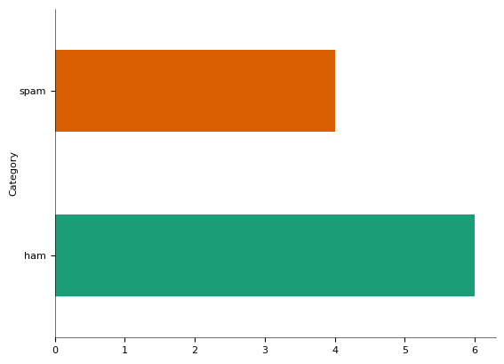

```python
import pandas as pd

df = pd.read_csv("/content/drive/MyDrive/Colab Notebooks/Email-span/spam.csv", encoding='ISO-8859-1')
df.head(10)
```

```python
df['Category'].value_counts()
```

```
Category
ham     4825
spam     747
Name: count, dtype: int64
```

```python
747/4825
```

```
0.15481865284974095
```

```python
df_spam = df[df['Category']=='spam']
df_spam.shape
```

```
(747, 2)
```

```python
df_ham = df[df['Category']=='ham']
df_ham.shape
```

```
(4825, 2)
```

```python
df_ham_downsampled = df_ham.sample(df_spam.shape[0])
df_ham_downsampled.shape
```

```
(747, 2)
```

```python
df_balanced = pd.concat([df_ham_downsampled, df_spam])
df_balanced.shape
```

```
(1494, 2)
```

```python
df_balanced['Category'].value_counts()
```

```
Category
ham     747
spam    747
Name: count, dtype: int64
```

```python
df_balanced['spam']=df_balanced['Category'].apply(lambda x: 1 if x=='spam' else 0)
df_balanced.sample(10)
```

|  | Category | Message | spam |
| --- | --- | --- | --- |
| 5461 | ham | Ok i thk i got it. Then u wan me 2 come now or... | 0 |
| 833 | ham | Thank you so much. When we skyped wit kz and s... | 0 |
| 2260 | spam | SplashMobile: Choose from 1000s of gr8 tones e... | 1 |
| 1289 | ham | Hey...Great deal...Farm tour 9am to 5pm $95/pa... | 0 |
| 2218 | ham | Nice talking to you! please dont forget my pix... | 0 |
| 54 | spam | SMS. ac Sptv: The New Jersey Devils and the De... | 1 |
| 246 | ham | I asked you to call him now ok | 0 |
| 5190 | spam | Our records indicate u maybe entitled to 5000 ... | 1 |
| 4983 | spam | goldviking (29/M) is inviting you to be his fr... | 1 |
| 186 | ham | Haha awesome, be there in a minute | 0 |

#### Split it into training and test data set

```python
from sklearn.model_selection import train_test_split

X_train, X_test, y_train, y_test = train_test_split(df_balanced['Message'],df_balanced['spam'], stratify=df_balanced['spam'])
```

```python
bert_preprocess = hub.KerasLayer("https://tfhub.dev/tensorflow/bert_en_uncased_preprocess/3")
bert_encoder = hub.KerasLayer("https://tfhub.dev/tensorflow/bert_en_uncased_L-12_H-768_A-12/4")
```

#### Build A Functional Model

```python
# Bert layers
text_input = tf.keras.layers.Input(shape=(), dtype=tf.string, name='text')
preprocessed_text = bert_preprocess(text_input)
outputs = bert_encoder(preprocessed_text)

# Neural network layers
l = tf.keras.layers.Dropout(0.1, name="dropout")(outputs['pooled_output'])
l = tf.keras.layers.Dense(1, activation='sigmoid', name="output")(l)

# Use inputs and outputs to construct a final model
model = tf.keras.Model(inputs=[text_input], outputs = [l])
```

```python
#to visualize
%pip install pydot
%pip install pydotplus
%pip install graphviz
```

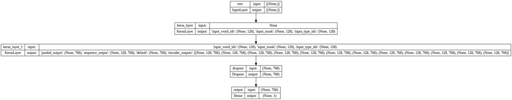

```python
from keras.utils import plot_model
plot_model(model, to_file='model_plot.png', show_shapes=True, show_layer_names=True)
```

```python
model.summary()
```

```
Model: "model"
__________________________________________________________________________________________________
 Layer (type)                   Output Shape         Param #     Connected to
==================================================================================================
 text (InputLayer)              [(None,)]            0           []

 keras_layer (KerasLayer)       {'input_word_ids':   0           ['text[0][0]']
                                (None, 128),
                                 'input_mask': (Non
                                e, 128),
                                 'input_type_ids':
                                (None, 128)}

 keras_layer_1 (KerasLayer)     {'pooled_output': (  109482241   ['keras_layer[0][0]',
                                None, 768),                       'keras_layer[0][1]',
                                 'sequence_output':               'keras_layer[0][2]']
                                 (None, 128, 768),
                                 'default': (None,
                                768),
                                 'encoder_outputs':
                                 [(None, 128, 768),
                                 (None, 128, 768),
                                 (None, 128, 768),
                                 (None, 128, 768),
                                 (None, 128, 768),
                                 (None, 128, 768),
                                 (None, 128, 768),
                                 (None, 128, 768),
                                 (None, 128, 768),
                                 (None, 128, 768),
                                 (None, 128, 768),
                                 (None, 128, 768)]}

 dropout (Dropout)              (None, 768)          0           ['keras_layer_1[0][13]']

 output (Dense)                 (None, 1)            769         ['dropout[0][0]']

==================================================================================================
Total params: 109,483,010
Trainable params: 769
Non-trainable params: 109,482,241
__________________________________________________________________________________________________
```

```python
METRICS = [
      tf.keras.metrics.BinaryAccuracy(name='accuracy'),
      tf.keras.metrics.Precision(name='precision'),
      tf.keras.metrics.Recall(name='recall')
]

model.compile(optimizer='adam',
              loss='binary_crossentropy',
              metrics=METRICS)
```